# FigureYa280TMEofSTS

**Author(s)**: Xiaofan Lu; Yasi Zhang  
**Reviewer(s)**: Ying Ge  
**Date**: 2025-05-20

# 需求描述

# Demand description

软组织肉瘤（STSs）

Soft-tissue sarcomas (STSs)

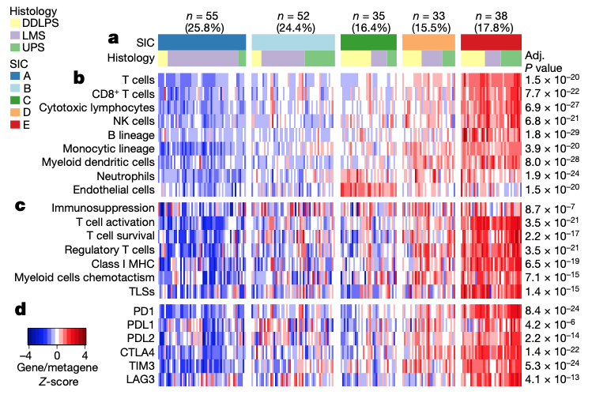

出自：https://www.nature.com/articles/s41586-019-1906-8

图1 | SICs表现出显著不同的肿瘤微环境（TME）。本图基于TCGA SARC队列（n = 213）。a. 按SIC和组织学类型划分的TCGA SARC队列构成。b. 通过MCP-counter Z值定义的各SIC组TME组成。NK细胞指自然杀伤细胞。c. 按SIC分组的免疫TME功能相关基因标志物表达。d. 按SIC分组的免疫检查点相关基因表达。校正P值通过双侧Kruskal-Wallis检验的Benjamini-Hochberg校正获得。

Source: https://www.nature.com/articles/s41586-019-1906-8

Fig. 1 | The SICs exhibit strongly different TMEs. This figure refers to the TCGA SARC cohort (n = 213). a, Composition of the TCGA SARC cohort by SIC, and histology. b, Composition of the TME by SIC as defined by the MCP-counter Z- scores. NK cells, natural killer cells. c, Expression of gene signatures related to the functional orientation of the immune TME by SIC. d, Expression of genes related to immune checkpoints by SIC. Adjusted P values are obtained from Benjamini–Hochberg correction of two-sided Kruskal–Wallis tests P values.

# 应用场景

# Application scenarios

用MCPcounter计算免疫富集得分，根据MCPcounter结果进行分型。

我们曾众筹过FigureYa56immune_inflitration，也是用TCGA的表达数据计算免疫浸润，并画热图。我们这次画的图信息更丰富。

The immune enrichment scores were calculated using MCP-counter, and subtyping was performed based on the MCP-counter results.

We previously conducted a crowdfunding project (FigureYa56immune_infiltration), which also used TCGA expression data to compute immune infiltration and generate heatmaps. However, the current visualization provides more comprehensive analytical dimensions.

# 环境设置

# Environment Setup

使用国内镜像安装包。

Using domestic mirrors for package installation.

```r
options("repos"= c(CRAN="https://mirrors.tuna.tsinghua.edu.cn/CRAN/"))
options(BioC_mirror="http://mirrors.tuna.tsinghua.edu.cn/bioconductor/")
install.packages("devtools")
library(devtools)
install_github("ebecht/MCPcounter",ref="master", subdir="Source")
```

# 加载包

# Loading packages

```r
library(MCPcounter)
```

```r
library(GSVA)
library(ComplexHeatmap)
library(ClassDiscovery)
library(gplots)
library(RColorBrewer)

# 自定义函数
# Custom Function
standarize.fun <- function(indata=NULL, halfwidth=NULL, centerFlag=T, scaleFlag=T) {
  outdata=t(scale(t(indata), center=centerFlag, scale=scaleFlag))
  if (!is.null(halfwidth)) {
    outdata[outdata>halfwidth]=halfwidth
    outdata[outdata<(-halfwidth)]= -halfwidth
  }
  return(outdata)
}

# 显示英文报错信息
# Show English error messages
Sys.setenv(LANGUAGE = "en")

# 禁止chr转成factor
# Prevent character-to-factor conversion
options(stringsAsFactors = FALSE)
```

# 输入文件

# Input Files

从XENA下载数据：

TCGA-SARC.star_fpkm.tsv.gz，表达谱数据FPKM，已经过`log2(fpkm+1)`转换，下载地址：https://xenabrowser.net/datapages/?dataset=TCGA-SARC.star_fpkm.tsv&host=https%3A%2F%2Fgdc.xenahubs.net&removeHub=https%3A%2F%2Fxena.treehouse.gi.ucsc.edu%3A443

gencode.v36.annotation.gtf.gene.probemap，ID/Gene Mapping，下载地址同上。

TCGA-SARC.clinical.tsv.gz，临床信息，下载地址：https://xenabrowser.net/datapages/?dataset=TCGA-SARC.clinical.tsv&host=https%3A%2F%2Fgdc.xenahubs.net&removeHub=https%3A%2F%2Fxena.treehouse.gi.ucsc.edu%3A443

Data downloaded from XENA:

TCGA-SARC.star_fpkm.tsv.gz, expression profile data FPKM, already transformed by `log2(fpkm+1)`, download link: https://xenabrowser.net/datapages/?dataset=TCGA-SARC.star_fpkm.tsv&host=https%3A%2F%2Fgdc.xenahubs.net&removeHub=https%3A%2F%2Fxena.treehouse.gi.ucsc.edu%3A443

gencode.v36.annotation.gtf.gene.probemap, ID/Gene Mapping, download link same as above.

TCGA-SARC.clinical.tsv.gz, clinical information, download link: https://xenabrowser.net/datapages/?dataset=TCGA-SARC.clinical.tsv&host=https%3A%2F%2Fgdc.xenahubs.net&removeHub=https%3A%2F%2Fxena.treehouse.gi.ucsc.edu%3A443

```r
# 读取XENA下载的FPKM表达谱数据
# Read FPKM expression profile data downloaded from XENA
fpkm <- read.table("TCGA-SARC.star_fpkm.tsv.gz", row.names = 1,check.names = F,stringsAsFactors = F,header = T)
Ginfo <- read.table("gencode.v36.annotation.gtf.gene.probemap", row.names = 1,check.names = F,stringsAsFactors = F,header = T)

# 获取表达数据和基因注释之间的共有基因
# Get common genes between expression data and gene annotation
comgene <- intersect(rownames(fpkm), rownames(Ginfo))
fpkm <- fpkm[comgene,]
Ginfo <- Ginfo[comgene,]

# 添加基因符号并按中位数表达量聚合
# Add gene symbols and aggregate by median expression
fpkm$gene <- Ginfo[rownames(fpkm),"gene"]
fpkm <- as.data.frame(apply(fpkm[,setdiff(colnames(fpkm), "gene")], 2, function(x) tapply(x, INDEX=factor(fpkm$gene), FUN=median, na.rm=TRUE)))

# 根据原文设置感兴趣签名
#Define signatures of interest as per the original text
immunosuppression.signature <- c("CXCL12","TGFB1","TGFB3","LGALS1")
t.cell.activation.signature <- c("CXCL9","CXCL10","CXCL16","IFNG","IL15")
t.cell.survival.signature <- c("CD70","CD27")
regulatory.t.cell.signature <- c("FOXP3","TNFRSF18")
mhc.signature <- c("HLA-A","HLA-B","HLA-E","HLA-F","HLA-G","B2M")
myeloid.signature <- "CCL2"
tls.signature <- "CXCL13"

# 免疫检查点靶点基因（分别为PD1, PDL1, PDL2, CTLA4, TIM3和LAG3）
# Immune checkpoint target genes (PD1, PDL1, PDL2, CTLA4, TIM3 and LAG3)
ici.gene <- c("PDCD1","CD274","PDCD1LG2","CTLA4","HAVCR2","LAG3")

# 检查这些签名基因是否可以被匹配
# Check if these signature genes can be matched
is.element(immunosuppression.signature, rownames(fpkm))
```

```
## [1] TRUE TRUE TRUE TRUE
```

```r
is.element(t.cell.activation.signature, rownames(fpkm))
```

```
## [1] TRUE TRUE TRUE TRUE TRUE
```

```r
is.element(t.cell.survival.signature, rownames(fpkm))
```

```
## [1] TRUE TRUE
```

```r
is.element(regulatory.t.cell.signature, rownames(fpkm))
```

```
## [1] TRUE TRUE
```

```r
is.element(mhc.signature, rownames(fpkm))
```

```
## [1] TRUE TRUE TRUE TRUE TRUE TRUE
```

```r
is.element(myeloid.signature, rownames(fpkm))
```

```
## [1] TRUE
```

```r
is.element(tls.signature, rownames(fpkm))
```

```
## [1] TRUE
```

```r
is.element(ici.gene, rownames(fpkm))
```

```
## [1] TRUE TRUE TRUE TRUE TRUE TRUE
```

```r
# 加载临床信息并获取共有的样本
# Load clinical information and get common samples
sinfo <- read.delim(file = "TCGA-SARC.clinical.tsv.gz", sep = "\t",row.names = 1,check.names = F,stringsAsFactors = F,header = T)
comsam <- intersect(rownames(sinfo), colnames(fpkm))
sinfo <- sinfo[comsam,]
fpkm <- fpkm[,comsam]
```

# 计算免疫富集得分，聚类分析

# Calculate immune enrichment scores and perform cluster analysis

```r
# 计算免疫富集得分
# 这里读取的genes.txt和probesets.txt出自MCPcounter包，这样操作速度更快
# Calculate immune enrichment scores and perform cluster analysis
# The genes.txt and probesets.txt here are from the MCPcounter package for faster processing
mcp <- MCPcounter.estimate(fpkm,
                           featuresType = "HUGO_symbols",
                           genes = read.table("genes.txt",sep = "\t",stringsAsFactors = F,header = T,colClasses = "character",check.names = F),
                           probesets = read.table("probesets.txt",sep = "\t",stringsAsFactors = F,header = F,colClasses = "character",check.names = F))
mcp <- mcp[-10, ] # 根据原文移除纤维化，剩下9种细胞

# 对MCPcounter得分进行聚类分析
# Cluster analysis of MCPcounter scores
indata <- t(scale(t(mcp)))
hcs <- hclust(distanceMatrix(as.matrix(indata), "euclidean"), "ward.D") # 原文提到使用欧式距离以及ward's聚类方式
group <- cutree(hcs, k = 5) # 原文分为5类
group <- paste0("C", group); names(group) <- colnames(mcp)

# 先简单绘图看一下趋势
# First make a simple plot to observe the trend
indata <- mcp
plotdata <- standarize.fun(indata, halfwidth = 2)

# 设置颜色
# Set colors
sic.col <- c("#2B7AB5", "#ABD9E8", "#339E2B", "#FDAE61", "#D71719")
hit.col <- c("#FFFF99", "#BDAED4", "#7DC77D", "#FFD700", "#87CEEB", "#FFA07A")

hm <- pheatmap(plotdata,
         border_color = NA,
         color = bluered(64),
         show_rownames = T,
         show_colnames = F,
         cutree_cols = 5,
         cluster_rows = F,
         cluster_cols = hcs,
         name = "MCPcounter",
         cellheight = 12,
         cellwidth = 300/ncol(plotdata),
         annotation_col = data.frame(row.names = colnames(plotdata),
                                     SIC = group[colnames(plotdata)]),
         annotation_colors = list(SIC = c("C1" = sic.col[1],
                                          "C2" = sic.col[2],
                                          "C3" = sic.col[3],
                                          "C4" = sic.col[4],
                                          "C5" = sic.col[5])))
pdf(file = "heatmap for refer.pdf", width = 8,height = 4)
draw(hm)
invisible(dev.off())

# 根据此热图对样本进行修正和排序，并将组别映射到新的字母顺序
# Correct and sort samples based on this heatmap, and map groups to new alphabetical order
sic <- sapply(group,function(x) {
  switch(x,
         "C1" = "B",
         "C2" = "A",
         "C3" = "C",
         "C4" = "D",
         "C5" = "E")})

# 计算其他签名
# Calculate other signatures
geoMean <- function(x) {exp(mean(log(x)))}
immunosuppression.geoMean <- apply(fpkm[immunosuppression.signature,], 2, geoMean)
t.cell.activation.geoMean <- apply(fpkm[t.cell.activation.signature,], 2, geoMean)
t.cell.survival.geoMean <- apply(fpkm[t.cell.survival.signature,], 2, geoMean)
regulatory.t.cell.geoMean <- apply(fpkm[regulatory.t.cell.signature,], 2, geoMean)
mhc.geoMean <- apply(fpkm[mhc.signature,], 2, geoMean)
myeloid.geoMean <- apply(fpkm[myeloid.signature,], 2, geoMean)
tls.geoMean <- apply(fpkm[tls.signature,], 2, geoMean)

# 将签名得分合并
# Combine signature scores
tme.dat <- data.frame("Immunosuppression" = immunosuppression.geoMean,
                      "T cell activation" = t.cell.activation.geoMean,
                      "T cell survival" = t.cell.survival.geoMean,
                      "Regulatory T cell" = regulatory.t.cell.geoMean,
                      "Class I MHC" = mhc.geoMean,
                      "Myeloid cells chemotactism" = myeloid.geoMean,
                      "TLSs" = tls.geoMean)

# 组间比较并计算p值
# Inter-group comparison and p-value calculation
outTab <- NULL
indata <- as.data.frame(t(rbind.data.frame(mcp, t(tme.dat), fpkm[ici.gene,])))
indata$SIC <- sic[rownames(indata)]
for (i in setdiff(colnames(indata), "SIC")) {
  kt <- kruskal.test(as.numeric(indata[,i]) ~ indata$SIC)
  outTab <- rbind.data.frame(outTab,
                             data.frame(feature = i,
                                        p = kt$p.value,
                                        stringsAsFactors = F),
                             stringsAsFactors = F)
}

# 矫正p值
# Adjusted p-values
outTab$fdr <- p.adjust(outTab$p, method = "fdr")

# 将FDR改为科学计数法
# Convert FDR to scientific notation
outTab$txt <- formatC(outTab$fdr, digits = 2, format = "e")

# 修改文本
# Modify text
outTab$txt <- gsub("e"," × 10", outTab$txt)

rownames(outTab) <- outTab$feature
write.table(outTab, file = "kruskal waills test among different sic groups.txt",sep = "\t",row.names = F,col.names = T,quote = F)
```

# 开始画图

# Plotting

```r
# 创建列注释和对应颜色
# Create column annotations and corresponding colors
annCol <- data.frame(row.names = comsam,
                     Disease = sinfo$disease_type,
                     SIC = sic,
                     stringsAsFactors = F)

# 简化疾病类型名称
# Simplify disease type names
annCol$Disease <- sapply(annCol$Disease,function(x) {
  switch(x,
         "Myomatous Neoplasms" = "MN",
         "Nerve Sheath Tumors" = "NST",
         "Lipomatous Neoplasms" = "LN",
         "Fibromatous Neoplasms" = "FN",
         "Soft Tissue Tumors and Sarcomas, NOS" = "STT or STS",
         "Synovial-like Neoplasms" = "SLN")})


# 设置Disease的因子水平
# Set factor levels for Disease
annCol$Disease <- factor(annCol$Disease, levels = c("MN", "NST", "LN", "FN", "SLN", "STT or STS"))

# 按SIC和Disease排序
# Order by SIC and Disease
annCol <- annCol[order(annCol$SIC, annCol$Disease),,drop = F]

# 定义注释的颜色方案
# Define color schemes for annotations
annColors <- list()

# SIC颜色映射
# SIC color mapping
annColors[["SIC"]] <- c("A" = sic.col[1],
                        "B" = sic.col[2],
                        "C" = sic.col[3],
                        "D" = sic.col[4],
                        "E" = sic.col[5])

# Disease颜色映射
# Disease color mapping
annColors[["Disease"]] <- c("MN" = hit.col[1],
                              "NST" = hit.col[2],
                              "LN" = hit.col[3],
                              "FN" = hit.col[4],
                              "SLN" = hit.col[5],
                              "STT or STS" = hit.col[6])

# 重新绘图
# Re-draw heatmaps

## MCPcounter部分
## MCPcounter section
indata <- mcp
plotdata <- standarize.fun(indata, halfwidth = 2)

# 将签名和矫正p值的文本合并
# Append adjusted p-values to row names
rownames(plotdata) <- paste(rownames(plotdata), outTab[rownames(plotdata), "txt"], sep = " ")

hm1 <- pheatmap(plotdata[,rownames(annCol)],
               border_color = NA,
               color = bluered(64),
               show_rownames = T,
               show_colnames = F,
               cluster_rows = F,
               cluster_cols = F,
               name = "Gene/metagene\nZ-score",
               cellheight = 12,
               cellwidth = 300/ncol(plotdata),
               gaps_col = cumsum(table(annCol$SIC)),
               annotation_col = annCol,
               annotation_colors = annColors)

## 其他免疫签名部分
## Other immune signatures section
plotdata <- standarize.fun(t(tme.dat), halfwidth = 2)
rownames(plotdata) <- paste(rownames(plotdata), outTab[rownames(plotdata), "txt"], sep = " ")
hm2 <- pheatmap(plotdata[,rownames(annCol)],
                border_color = NA,
                color = bluered(64),
                show_rownames = T,
                show_colnames = F,
                cluster_rows = F,
                cluster_cols = F,
                name = "Gene/metagene\nZ-score",
                cellheight = 12,
                cellwidth = 300/ncol(plotdata),
                gaps_col = cumsum(table(annCol$SIC)))

## 免疫检查点表达部分
## Immune checkpoint expression section
plotdata <- standarize.fun(fpkm[ici.gene,], halfwidth = 2)
rownames(plotdata) <- paste(rownames(plotdata), outTab[rownames(plotdata), "txt"], sep = " ")
hm3 <- pheatmap(plotdata[,rownames(annCol)],
                border_color = NA,
                color = bluered(64),
                show_rownames = T,
                show_colnames = F,
                cluster_rows = F,
                cluster_cols = F,
                name = "Gene/metagene\nZ-score",
                cellheight = 12,
                cellwidth = 300/ncol(plotdata),
                gaps_col = cumsum(table(annCol$SIC)))

# 保存合并的热图到PDF
# Save combined heatmaps to PDF
pdf(file = "TMEheatmap.pdf", width = 10,height = 6)
draw(hm1 %v% hm2 %v% hm3,
     heatmap_legend_side = "left",
     annotation_legend_side = "left")
invisible(dev.off())
```

# 会话信息